```python
pip install pandas numpy matplotlib seaborn scikit-learn
```

```python
pip install --upgrade pip
```

# Import Libraries

```python
import pandas as pd
import numpy as np

import matplotlib.pyplot as plt
import seaborn as sns

from sklearn.model_selection import train_test_split
from sklearn.preprocessing import LabelEncoder
from sklearn.preprocessing import StandardScaler

from sklearn.linear_model import LogisticRegression
from sklearn.tree import DecisionTreeClassifier
from sklearn.ensemble import RandomForestClassifier
from sklearn.neighbors import KNeighborsClassifier

from sklearn.metrics import accuracy_score
from sklearn.metrics import classification_report
from sklearn.metrics import confusion_matrix
from sklearn.metrics import roc_curve, roc_auc_score

from sklearn.model_selection import GridSearchCV

import pickle

import warnings
warnings.filterwarnings('ignore')
```

# Load Dataset

```python
df = pd.read_csv("loan.csv")
df.head()
```

|  | Loan_ID | Gender | Married | Dependents | Education | Self_Employed | ApplicantIncome | CoapplicantIncome | LoanAmount | Loan_Amount_Term | Credit_History | Property_Area | Loan_Status |
| --- | --- | --- | --- | --- | --- | --- | --- | --- | --- | --- | --- | --- | --- |
| 0 | LP001002 | Male | No | 0 | Graduate | No | 5849 | 0.0 | NaN | 360.0 | 1.0 | Urban | Y |
| 1 | LP001003 | Male | Yes | 1 | Graduate | No | 4583 | 1508.0 | 128.0 | 360.0 | 1.0 | Rural | N |
| 2 | LP001005 | Male | Yes | 0 | Graduate | Yes | 3000 | 0.0 | 66.0 | 360.0 | 1.0 | Urban | Y |
| 3 | LP001006 | Male | Yes | 0 | Not Graduate | No | 2583 | 2358.0 | 120.0 | 360.0 | 1.0 | Urban | Y |
| 4 | LP001008 | Male | No | 0 | Graduate | No | 6000 | 0.0 | 141.0 | 360.0 | 1.0 | Urban | Y |

```python
df.tail()
```

|  | Loan_ID | Gender | Married | Dependents | Education | Self_Employed | ApplicantIncome | CoapplicantIncome | LoanAmount | Loan_Amount_Term | Credit_History | Property_Area | Loan_Status |
| --- | --- | --- | --- | --- | --- | --- | --- | --- | --- | --- | --- | --- | --- |
| 609 | LP002978 | Female | No | 0 | Graduate | No | 2900 | 0.0 | 71.0 | 360.0 | 1.0 | Rural | Y |
| 610 | LP002979 | Male | Yes | 3+ | Graduate | No | 4106 | 0.0 | 40.0 | 180.0 | 1.0 | Rural | Y |
| 611 | LP002983 | Male | Yes | 1 | Graduate | No | 8072 | 240.0 | 253.0 | 360.0 | 1.0 | Urban | Y |
| 612 | LP002984 | Male | Yes | 2 | Graduate | No | 7583 | 0.0 | 187.0 | 360.0 | 1.0 | Urban | Y |
| 613 | LP002990 | Female | No | 0 | Graduate | Yes | 4583 | 0.0 | 133.0 | 360.0 | 0.0 | Semiurban | N |

# Dataset Information

```python
df.shape
```

```
(614, 13)
```

```python
df.info()
```

```
<class 'pandas.core.frame.DataFrame'>
RangeIndex: 614 entries, 0 to 613
Data columns (total 13 columns):
 #   Column             Non-Null Count  Dtype
---  ------             --------------  -----
 0   Loan_ID            614 non-null    object
 1   Gender             601 non-null    object
 2   Married            611 non-null    object
 3   Dependents         599 non-null    object
 4   Education          614 non-null    object
 5   Self_Employed      582 non-null    object
 6   ApplicantIncome    614 non-null    int64
 7   CoapplicantIncome  614 non-null    float64
 8   LoanAmount         592 non-null    float64
 9   Loan_Amount_Term   600 non-null    float64
 10  Credit_History     564 non-null    float64
 11  Property_Area      614 non-null    object
 12  Loan_Status        614 non-null    object
dtypes: float64(4), int64(1), object(8)
memory usage: 62.5+ KB
```

```python
df.describe()
```

[output not shown]

# Handling Missing Values

```python
df.isnull().sum()
```

```
Loan_ID               0
Gender               13
Married               3
Dependents           15
Education             0
Self_Employed        32
ApplicantIncome       0
CoapplicantIncome     0
LoanAmount           22
Loan_Amount_Term     14
Credit_History       50
Property_Area         0
Loan_Status           0
dtype: int64
```

```python
cat_cols = ['Gender', 'Married', 'Dependents',
            'Self_Employed', 'Loan_Amount_Term',
            'Credit_History']

for col in cat_cols:
    df[col] = df[col].fillna(df[col].mode()[0])
```

```python
df['LoanAmount'] = df['LoanAmount'].fillna(df['LoanAmount'].mean())
```

# Exploratory Data Analysis (EDA)

## Loan Status Distribution

[figure not shown]

```python
plt.figure(figsize=(6,4))
sns.countplot(x='Loan_Status', data=df)
plt.title("Loan Approval Distribution")
plt.show()
```

- The dataset contains more approved loans than rejected loans.
- This indicates that the majority of applicants in the dataset were eligible for loan approval.

## Gender vs Loan Status

[figure not shown]

```python
plt.figure(figsize=(6,4))
sns.countplot(x='Gender', hue='Loan_Status', data=df)
plt.title("Gender vs Loan Status")
plt.show()
```

- Loan approvals are higher for both genders.
- The dataset also contains a larger number of male applicants compared to female applicants.

## Education vs Loan Status

[figure not shown]

```python
plt.figure(figsize=(6,4))
sns.countplot(x='Education', hue='Loan_Status', data=df)
plt.title("Education vs Loan Status")
plt.show()
```

- Loan approvals are higher across both education categories.
- Applicants with graduate-level education appear more frequently in the dataset and show a higher number of approved loans.

## Applicant Income Distribution

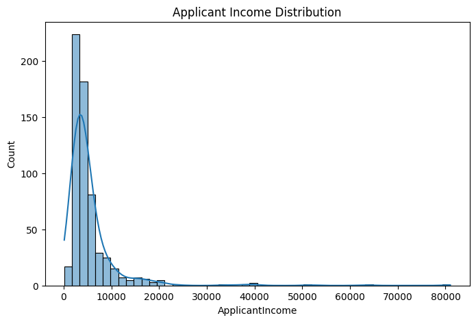

```python
plt.figure(figsize=(8,5))
sns.histplot(df['ApplicantIncome'], kde=True)
plt.title("Applicant Income Distribution")
plt.show()
```

- Most applicants fall within the lower to medium income range.
- The distribution is right-skewed, indicating the presence of a few applicants with very high incomes.

# Feature Engineering

## Total Income Feature

```python
df['Total_Income'] = (
    df['ApplicantIncome']
    + df['CoapplicantIncome']
)
```

## Income Loan Ratio

```python
df['Income_Loan_Ratio'] = (
    df['Total_Income']
    / df['LoanAmount']
)
```

## EMI Feature

```python
df['EMI'] = (
    df['LoanAmount']
    / df['Loan_Amount_Term']
)
```

# Encode Categorical Variables

```python
le = LabelEncoder()

categorical_cols = [
    'Gender',
    'Married',
    'Education',
    'Self_Employed',
    'Property_Area',
    'Loan_Status',
    'Dependents'
]

for col in categorical_cols:
    df[col] = le.fit_transform(df[col])
```

# Correlation Heatmap

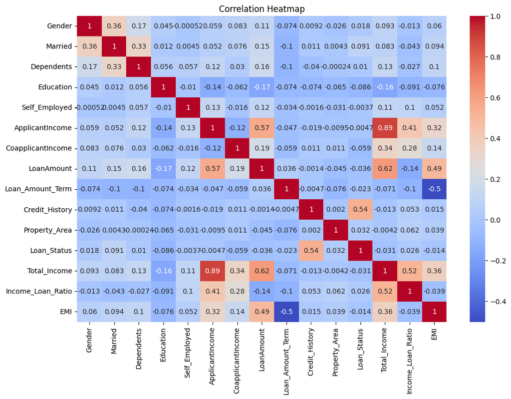

```python
plt.figure(figsize=(12,8))
sns.heatmap(df.corr(), annot=True, cmap='coolwarm')
plt.title("Correlation Heatmap")
plt.show()
```

- The heatmap shows relationships between different features.
- Credit_History has a relatively stronger positive correlation with Loan_Status, indicating it is an important factor in loan approval prediction.

# Split Features and Target

```python
X = df.drop('Loan_Status',axis=1)
y = df['Loan_Status']
```

# Train Test Split

```python
X_train, X_test, y_train, y_test = train_test_split(
    X,
    y,
    test_size=0.2,
    random_state=42
)
```

# Feature Scaling

```python
scaler = StandardScaler()
X_train_scaled = scaler.fit_transform(X_train)
X_test_scaled = scaler.transform(X_test)
```

# Logistic Regression

```python
lr = LogisticRegression(max_iter=5000)
lr.fit(X_train_scaled, y_train)
lr_pred = lr.predict(X_test_scaled)
lr_acc = accuracy_score(y_test, lr_pred)
print("Logistic Regression Accuracy:", lr_acc)
```

```
Logistic Regression Accuracy: 0.7804878048780488
```

# Decision Tree

```python
dt = DecisionTreeClassifier(random_state=42)
dt.fit(X_train, y_train)
dt_pred = dt.predict(X_test)
dt_acc = accuracy_score(y_test, dt_pred)
print("Decision Tree Accuracy:", dt_acc)
```

```
Decision Tree Accuracy: 0.7235772357723578
```

# Random Forest

```python
rf = RandomForestClassifier( n_estimators=100, random_state=42)
rf.fit(X_train, y_train)
rf_pred = rf.predict(X_test)
rf_acc = accuracy_score(y_test, rf_pred)
print("Random Forest Accuracy:", rf_acc)
```

```
Random Forest Accuracy: 0.7886178861788617
```

# KNN Model

```python
knn = KNeighborsClassifier( n_neighbors=5)
knn.fit(X_train_scaled, y_train)
knn_pred = knn.predict(X_test_scaled)
knn_acc = accuracy_score(y_test, knn_pred)
print("KNN Accuracy:", knn_acc)
```

```
KNN Accuracy: 0.7479674796747967
```

# Compare Model Accuracy

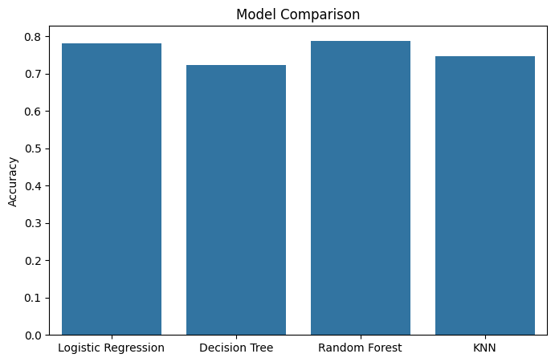

```python
models = [
    'Logistic Regression',
    'Decision Tree',
    'Random Forest',
    'KNN'
]

scores = [
    lr_acc,
    dt_acc,
    rf_acc,
    knn_acc
]

plt.figure(figsize=(8,5))
sns.barplot(x=models, y=scores)
plt.ylabel("Accuracy")
plt.title("Model Comparison")
plt.show()
```

- Random Forest achieved the highest accuracy among all models, making it the best-performing model for loan prediction.
- Decision Tree showed comparatively lower performance.